# 1. Questions

These are the questions we are going to focus in the analysis of Titanic Dataset. From my point of view, the most interesting questions are related to whether the passenger had survived or not. But I have added other questions as well.

- The fact of being alone aboard, makes easy to survive?
- Old people (> 65yo) or children (< 15yo) were more likely to survive?
- What were all the difference between classes?
- How many children lost their parents?
- Is the embarked port related to the age? or to the class?
- Was the sex and important factor?

# 2. Wrangling Data

```python
import pandas as pd # Importing libraries
import numpy as np
```

```python
titanic_df = pd.read_csv('/Users/dgcagigas/Documents/DataAnalyzer/P2/titanic-data.csv') # Read csv
```

After this we still have some missing values from Age and Embarked people. 169 ages are missing and 2 embarked people, we could calculate these values through medias however due to the low quantity I will delete these passengers in the questions we will analyze age or embarked people.

Using panda function, describe() and info(), we can see a summary of missing values and all data.

```python
titanic_df = titanic_df[titanic_df.Fare != 0]
titanic_df = titanic_df.drop(['Name', 'PassengerId', 'Ticket', 'Cabin'], axis=1)
```

```python
titanic_df.info()
```

```
<class 'pandas.core.frame.DataFrame'>
Int64Index: 876 entries, 0 to 890
Data columns (total 8 columns):
Survived    876 non-null int64
Pclass      876 non-null int64
Sex         876 non-null object
Age         707 non-null float64
SibSp       876 non-null int64
Parch       876 non-null int64
Fare        876 non-null float64
Embarked    874 non-null object
dtypes: float64(2), int64(4), object(2)
memory usage: 61.6+ KB
```

```python
titanic_df.describe()
```

|  | Survived | Pclass | Age | SibSp | Parch | Fare |
| --- | --- | --- | --- | --- | --- | --- |
| count | 876.000000 | 876.000000 | 707.000000 | 876.000000 | 876.000000 | 876.000000 |
| mean | 0.389269 | 2.315068 | 29.645219 | 0.531963 | 0.388128 | 32.755650 |
| std | 0.487863 | 0.835663 | 14.558872 | 1.110009 | 0.811374 | 49.936826 |
| min | 0.000000 | 1.000000 | 0.420000 | 0.000000 | 0.000000 | 4.012500 |
| 25% | 0.000000 | 2.000000 | NaN | 0.000000 | 0.000000 | 7.925000 |
| 50% | 0.000000 | 3.000000 | NaN | 0.000000 | 0.000000 | 14.500000 |
| 75% | 1.000000 | 3.000000 | NaN | 1.000000 | 0.000000 | 31.275000 |
| max | 1.000000 | 3.000000 | 80.000000 | 8.000000 | 6.000000 | 512.329200 |

# 3. Exploration Data and Draw Conclusions

## 3.1. The fact of being alone aboard, makes easy to survive?

```python
titanic_df['isAlone']= pd.Series((titanic_df.SibSp == 0) & (titanic_df.Parch == 0)) ## Adding column
```

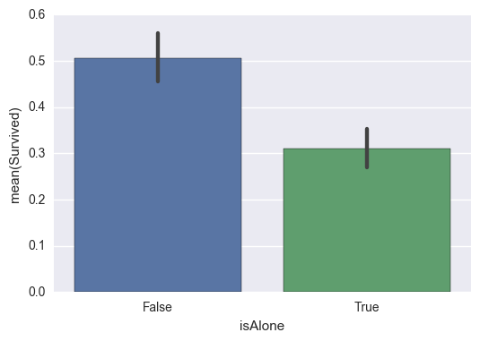

```python
import seaborn as sns
import matplotlib.pyplot as plt
%matplotlib inline

sns.barplot(data = titanic_df, x = 'isAlone', y = 'Survived')
sns.plt.show()
```

This shows a comparision between solo people survived and people with family aboard. It was clearly an advantage to have family aboard in order to survive.

## 3.2. Old people (> 65yo) or children (< 15yo) were likely to survive?

We have to delete passenger with age missing.

```python
titanicAge_df = titanic_df.drop(['Embarked'], axis=1).dropna() ## Delete Embarked Column and ages missed
```

```python
titanicAge_df['isOld'] = pd.Series(titanicAge_df.Age > 65) ## Adding column for old and young people
titanicAge_df['isYoung'] = pd.Series(titanicAge_df.Age < 15)
```

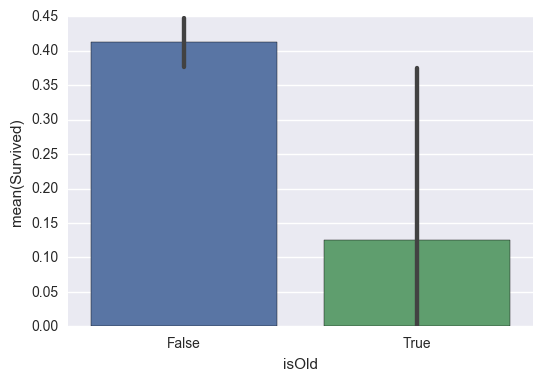

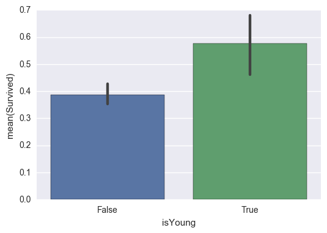

```python
sns.barplot(data = titanicAge_df, x = 'isOld', y = 'Survived')
sns.plt.show()
sns.barplot(data = titanicAge_df, x = 'isYoung', y = 'Survived')
sns.plt.show()
```

As you can see in the graphs, old people were likely to die. I will show now a graph with the survived people depending on the age.

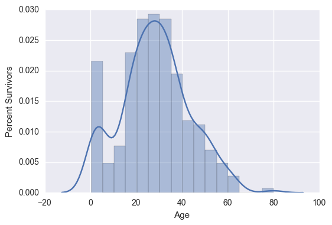

```python
ax = sns.distplot(titanicAge_df[titanicAge_df.Survived == 1].Age)
ax.set(xlabel='Age', ylabel='Percent Survivors')

sns.plt.show()
```

## 3.3. What were all the difference between classes?

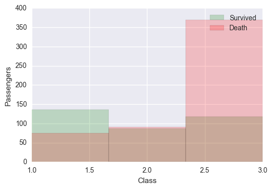

```python
plt.hist(titanic_df[titanic_df.Survived == True].Pclass, 3, facecolor = 'green', alpha = 0.2, label = 'Survived')
plt.hist(titanic_df[titanic_df.Survived == False].Pclass, 3, facecolor = 'red', alpha = 0.2, label = 'Death')
plt.legend()

plt.xlabel('Class')
plt.ylabel('Passengers')
plt.show()
```

We can see a big difference between people death from 1st or 2nd Class and people death from 3rd Class.

```python
Children = titanicAge_df[titanicAge_df.isYoung]
ChildrenD = Children[Children.Survived == 0] # Children deaths with parents aboard
print '%d Children died.' % len(ChildrenD)
```

```
33 Children died.
```

## 3.5. Is the embarked port related to the age? or to the class?

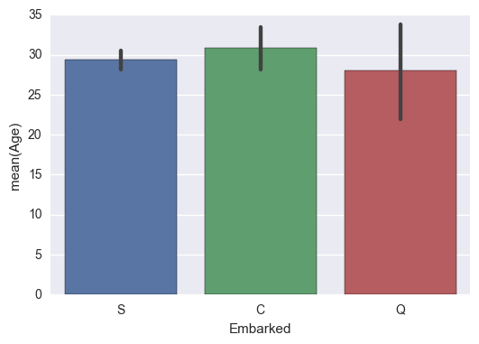

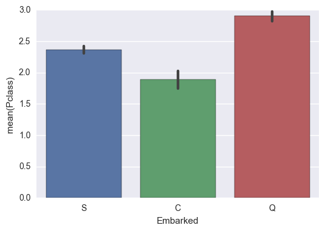

```python
titanicAge_df = titanic_df.dropna() ## Delete ages and embarked missed
sns.barplot(data = titanic_df, x = 'Embarked', y = 'Age')
sns.plt.show()
sns.barplot(data = titanic_df, x = 'Embarked', y = 'Pclass')
sns.plt.show()
```

Most of people in Queenstown seem to be 3rd Class.

## 3.6. Was the sex and important factor?

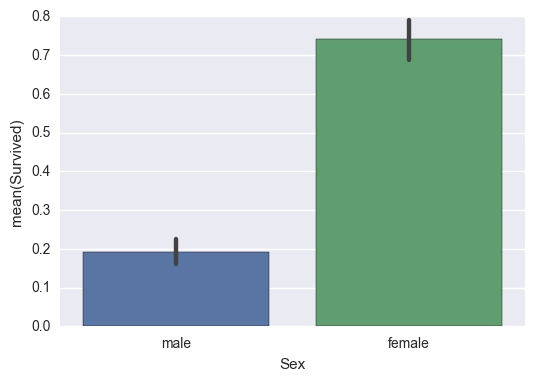

```python
sns.barplot(data = titanic_df, x = 'Sex', y = 'Survived')
sns.plt.show()
```

# 4. Communication